# Chap11_section6

Mijeong Kim

# Chapter 11 Forecasting hierarchical and grouped time series

```r
library(tsibble)
library(tsibbledata)
library(tibble)
library(dplyr)
library(knitr)
library(ggplot2)
library(fpp3)
library(fpp2)
library(seasonal)
library(feasts)
```

## 11.6 Forecasting Australian prison population

### 개요

이 절에서는 11.1절에서 소개한 호주 성인 교도소 수감자 자료를 이용해 grouped time series 예측을 수행한다. 여기서는 ETS 기초 모형 위에

- base forecast
- bottom-up forecast
- MinT reconciled forecast

를 비교한다.

테스트 구간은 자료의 마지막 2년, 즉 **2015년 1분기부터 2016년 4분기까지의 8개 분기**이다. 따라서 학습 구간은 2014년 4분기까지이다.

### 1. grouped structure 복습

교도소 자료는 단순 계층 구조가 아니라 다음 세 가지 속성이 교차하는 grouped structure이다.

- `State`
- `Legal`
- `Gender`

즉, 주별, 법적 지위별, 성별 분해가 동시에 존재하며, 이들이 하나의 고정된 계층으로 중첩되어 있지는 않다. 이러한 구조는 grouped time series의 전형적인 예이다.

앞 절에서 만든 자료 구조는 다음과 같다.

```r
prison <- readr::read_csv("https://OTexts.com/fpp3/extrafiles/prison_population.csv") |>
  mutate(Quarter = yearquarter(Date)) |>
  select(-Date)  |>
  as_tsibble(key = c(Gender, Legal, State, Indigenous),
             index = Quarter) |>
  relocate(Quarter)
```

```r
prison_gts <- prison |>
  aggregate_key(Gender * Legal * State, Count = sum(Count) / 1e3)
```

### 2. ETS 기초 모형과 reconciliation

원문에서는 각 시계열에 ETS 모형을 적합한 뒤, bottom-up과 MinT reconciliation을 비교한다.

```r
fit <- prison_gts |>
  filter(year(Quarter) <= 2014) |>
  model(base = ETS(Count)) |>
  reconcile(
    bottom_up = bottom_up(base),
    MinT = min_trace(base, method = "mint_shrink")
  )
```

그 후 8분기 ahead forecast를 생성한다.

```r
fc <- fit |>
  forecast(h = 8)
```

이때 `fc`에는 다음 세 종류의 예측이 함께 포함된다.

- `base`
- `bottom_up`
- `MinT`

### 3. 전체 호주 수감자 수 예측

가장 먼저 전체 호주 수감자 수의 예측을 그릴 수 있다.

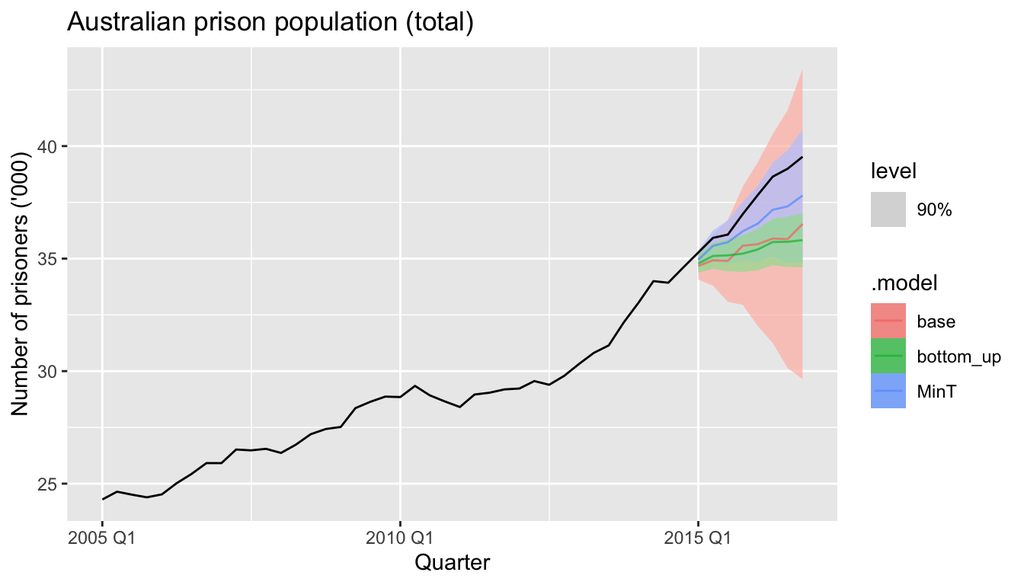

```r
fc |>
  filter(
    is_aggregated(State),
    is_aggregated(Gender),
    is_aggregated(Legal)
  ) |>
  autoplot(prison_gts, alpha = 0.7, level = 90) +
  labs(
    y = "Number of prisoners ('000)",
    title = "Australian prison population (total)"
  )
```

원문 해석에 따르면, 전체 수감자 수에서는 ETS 기반 `base`와 `bottom-up` 예측이 테스트 구간의 상승 추세를 과소추정하는 경향을 보인다. 반면 MinT는 grouped structure 전체의 base forecast 정보를 함께 사용하므로, 최상위 수준 예측을 위로 조정하게 된다.

또한 MinT의 예측구간은 base forecast보다 더 좁게 나타난다. 이는 MinT가 분산을 최소화하는 방식으로 구성되기 때문이다. 반면 base forecast의 분포는 incoherent하므로, 구조적 불일치에서 오는 추가 불확실성을 함께 안고 있다.

### 4. 주별 예측 비교

원문에서는 시각적 단순화를 위해 이후 그래프에서는 bottom-up을 제외하고 `base`와 `MinT`만 비교한다. 주별 예측은 다음과 같이 그릴 수 있다.

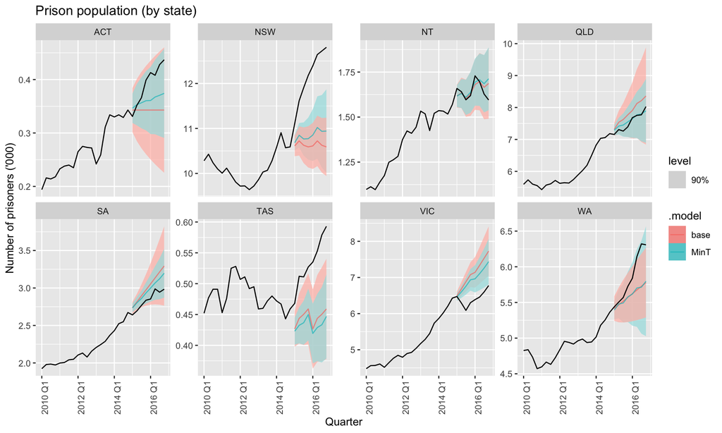

```r
fc |>
  filter(
    .model %in% c("base", "MinT"),
    !is_aggregated(State),
    is_aggregated(Legal),
    is_aggregated(Gender)
  ) |>
  autoplot(
    prison_gts |> filter(year(Quarter) >= 2010),
    alpha = 0.7, level = 90
  ) +
  labs(
    title = "Prison population (by state)",
    y = "Number of prisoners ('000)"
  ) +
  facet_wrap(vars(State), scales = "free_y", ncol = 4) +
  theme(axis.text.x = element_text(angle = 90, hjust = 1))
```

원문에서는 테스트 구간 전반에 걸쳐 대부분의 주에서 상승 추세가 나타난다고 설명한다. 특히

- `NSW`
- `TAS`

에서는 비교적 크고 갑작스러운 증가가 나타나며, 이 값들은 `base`와 `MinT` 모두의 예측구간 상한을 상당히 벗어난다. NSW는 규모가 가장 큰 주이므로, 이 급증은 국가 전체 수감자 수에도 큰 영향을 준다.

반면 `VIC`에서는 2015년 2분기와 3분기에 일시적인 하락이 나타난 뒤 다시 상승 추세로 돌아간다. 이러한 dip은 어떤 예측 방법도 잘 포착하지 못한다.

### 5. 법적 지위와 성별 수준의 예측

원문은 법적 지위별, 성별 예측도 함께 제시한다. 이 그래프들은 grouped structure의 다른 집계 경로에서 예측이 어떻게 달라지는지 보여준다.

법적 지위별 예측은 다음과 같이 그릴 수 있다.

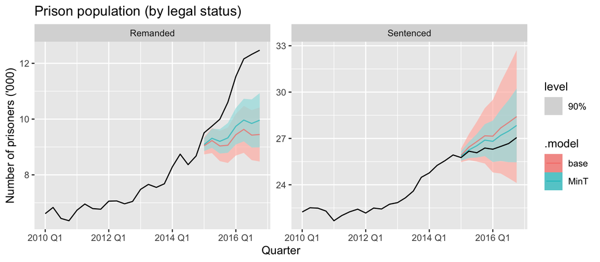

```r
fc |>
  filter(
    .model %in% c("base", "MinT"),
    is_aggregated(State),
    is_aggregated(Gender),
    !is_aggregated(Legal)
  ) |>
  autoplot(
    prison_gts |> filter(year(Quarter) >= 2010),
    alpha = 0.7, level = 90
  ) +
  labs(
    title = "Prison population (by legal status)",
    y = "Number of prisoners ('000)"
  ) +
  facet_wrap(vars(Legal), scales = "free_y")
```

성별 예측은 다음과 같이 그릴 수 있다.

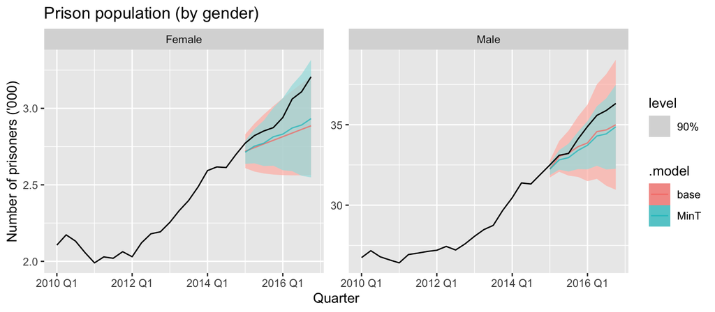

```r
fc |>
  filter(
    .model %in% c("base", "MinT"),
    is_aggregated(State),
    !is_aggregated(Gender),
    is_aggregated(Legal)
  ) |>
  autoplot(
    prison_gts |> filter(year(Quarter) >= 2010),
    alpha = 0.7, level = 90
  ) +
  labs(
    title = "Prison population (by gender)",
    y = "Number of prisoners ('000)"
  ) +
  facet_wrap(vars(Gender), scales = "free_y")
```

핵심적으로, 시각적으로 볼 때 MinT는 많은 series에서 base forecast를 테스트 구간 쪽 방향으로 조정한다. 즉, 모든 시계열에서 항상 더 좋아지는 것은 아니지만 평균적으로는 더 정확한 방향으로 이동시키는 경향이 있다.

### 6. bottom-level series 해석

원문 Figure 11.17은 bottom-level series 예측을 보여준다. 여기서는 네 개의 큰 주를 열 방향으로 놓고, 법적 지위와 성별 조합을 행 방향으로 두어 세부 series를 비교한다.

Figure 11.17에 해당하는 코드는 다음과 같다.

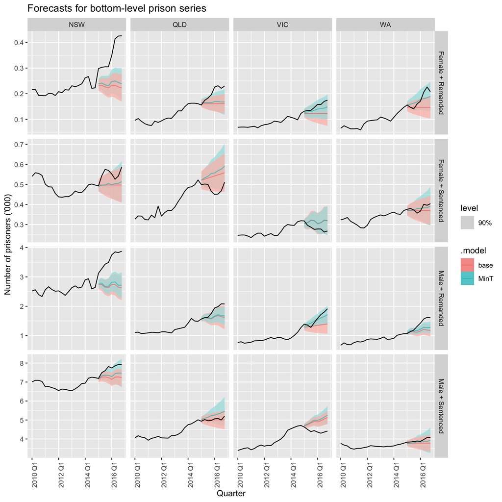

```r
fc_sel <- fc |>
  filter(
    .model %in% c("base", "MinT"),
    State %in% c("NSW", "QLD", "VIC", "WA"),
    !is_aggregated(State),
    !is_aggregated(Gender),
    !is_aggregated(Legal)
  ) |>
  mutate(
    series = factor(
      paste(as.character(Gender), as.character(Legal), sep = " + "),
      levels = c(
        "Female + Remanded",
        "Female + Sentenced",
        "Male + Remanded",
        "Male + Sentenced"
      )
    ),
    State = factor(as.character(State), levels = c("NSW", "QLD", "VIC", "WA"))
  )

data_sel <- prison_gts |>
  filter(
    year(Quarter) >= 2010,
    State %in% c("NSW", "QLD", "VIC", "WA"),
    !is_aggregated(State),
    !is_aggregated(Gender),
    !is_aggregated(Legal)
  ) |>
  mutate(
    series = factor(
      paste(as.character(Gender), as.character(Legal), sep = " + "),
      levels = c(
        "Female + Remanded",
        "Female + Sentenced",
        "Male + Remanded",
        "Male + Sentenced"
      )
    ),
    State = factor(as.character(State), levels = c("NSW", "QLD", "VIC", "WA"))
  )

fc_sel |>
  autoplot(data_sel, alpha = 0.7, level = 90) +
  labs(
    title = "Forecasts for bottom-level prison series",
    y = "Number of prisoners ('000)"
  ) +
  facet_grid(rows = vars(series), cols = vars(State), scales = "free_y") +
  theme(axis.text.x = element_text(angle = 90, hjust = 1))
```

이 그림에서 중요한 정책적 해석은 다음과 같다.

- 2015년 1분기부터 2016년 4분기까지의 큰 증가세는 주로 **remand prison population**의 증가에 의해 설명된다.
- 이 증가 패턴은 대체로 `base`와 `MinT` 모두 충분히 잘 예측하지 못한다.
- 다만 `NSW`에서는 remand뿐 아니라 **sentenced prison population**도 크게 증가한다.
- 특히 `NSW`의 sentenced male 증가가 주 및 전국 수감자 수 증가에 상당히 기여한다.

즉, grouped structure를 이용하면 단순히 전체 수감자 수 증가만 보는 것이 아니라, 어떤 하위 집단이 증가를 이끄는지까지 해석할 수 있다.

### 7. 정확도 평가

원문에서는 `accuracy()` 함수를 이용해 grouped structure 전체에서 예측 정확도를 평가한다. 전체 집계 수준의 예시는 다음과 같다.

```r
fc |>
  filter(
    is_aggregated(State),
    is_aggregated(Gender),
    is_aggregated(Legal)
  ) |>
  accuracy(
    data = prison_gts,
    measures = list(
      mase = MASE,
      ss = skill_score(CRPS)
    )
  ) |>
  group_by(.model) |>
  summarise(
    mase = mean(mase),
    sspc = mean(ss) * 100
  )
```

```
## # A tibble: 3 × 3
##   .model     mase  sspc
##   <chr>     <dbl> <dbl>
## 1 MinT      0.895  76.8
## 2 base      1.72   55.9
## 3 bottom_up 1.84   33.5
```

원문에서 전체 집계 수준 결과는 다음과 같다.

| Model | MASE | Skill score (CRPS, %) |
| --- | --- | --- |
| MinT | 0.895 | 76.8 |
| base | 1.72 | 55.9 |
| bottom_up | 1.84 | 33.5 |

즉, 전체 호주 수감자 수 예측에서는 MinT가 점예측 정확도와 분포 예측 정확도 모두에서 가장 우수하다.

원문 Table 11.3은 grouped structure의 각 수준별 결과를 다음과 같이 제시한다.

| Level | Base MASE | Bottom-up MASE | MinT MASE | Base Skill Score | Bottom-up Skill Score | MinT Skill Score |
| --- | --- | --- | --- | --- | --- | --- |
| Total | 1.72 | 1.84 | 0.90 | 55.91 | 33.46 | 76.80 |
| State | 2.12 | 1.88 | 1.78 | 6.40 | 24.10 | 22.46 |
| Legal status | 2.89 | 2.68 | 2.32 | 22.22 | 50.27 | 45.23 |
| Gender | 0.89 | 1.76 | 0.91 | 68.98 | 27.49 | 71.06 |
| Bottom | 2.23 | 2.23 | 2.06 | 0.93 | 0.93 | -3.23 |
| All series | 2.19 | 2.16 | 1.96 | 6.70 | 11.29 | 8.69 |

### 8. 결과 해석

원문에서는 서로 다른 집계 수준에서 수감자 수 규모가 크게 다르므로, **scaled measures**를 사용하는 것이 중요하다고 설명한다.

- `MASE`는 점예측 정확도의 scale-free 지표이다.
- `CRPS skill score`는 분포 예측 정확도의 상대적 척도이다.

해석 기준은 다음과 같다.

- `MASE`가 낮을수록 좋다.
- `Skill score`가 높을수록 좋다.

특히 grouped structure에서는 서로 다른 집계 경로의 정보를 동시에 활용할 수 있기 때문에, 특정 수준만 이용하는 방법보다 더 풍부한 정보를 반영할 수 있다. 이 점이 MinT의 정확도 개선으로 이어진다.